# ESM 204 Assignment 4 - Technical Appendix

Bridget Gibbons, BR Hoover

6/6/2019

### 1. Marginal Costs of Abatement for Sectors A, B, C, and D.

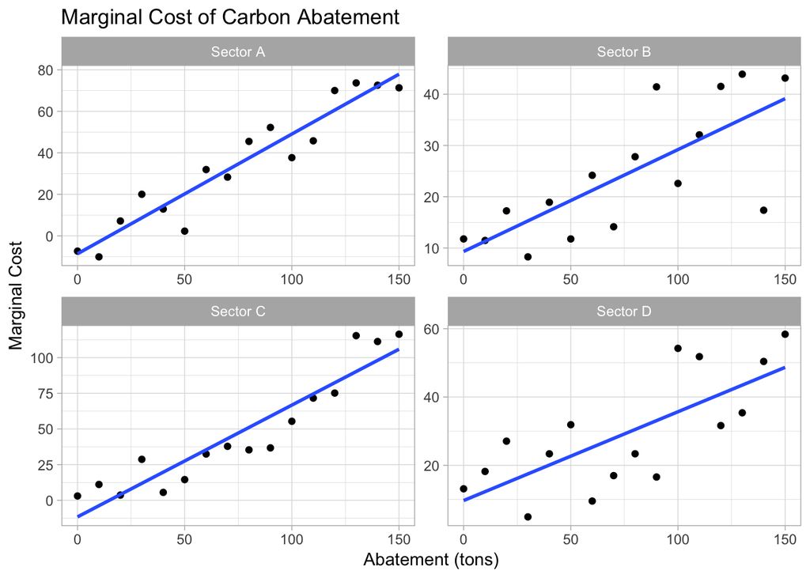

Marginal Cost of Abatement Functions:

- $$MC_A= -8.65 + 0.58(Abatement)$$
- $$MC_B= 9.32 + 0.2 (Abatement)$$
- $$MC_C = -11.66 + 0.78 (Abatement)$$
- $$MC_D = 9.69 + 0.26 (Abatement)$$

The marginal cost of abatement for each sector was determined using linear regression models.

### 2. Demand Curves for Carbon Emissions for Sectors A, B, C, and D

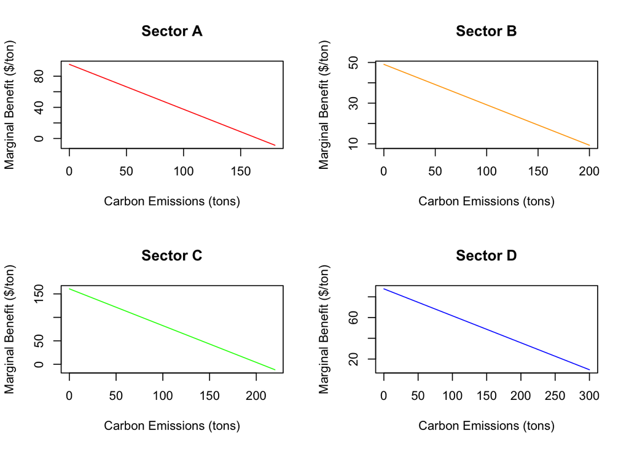

Demand for emission functions:
$$Demand_A = -0.58(Emissions) + 95.19$$
$$Demand_B = -0.2(Emissions) + 49.07$$
$$Demand_C =-0.78(Emissions) + 160.79$$
$$Demand_D = -0.26 (Emissions)+ 87.67$$

Sector C has the highest willingnesss to pay for the first unit of carbon emissions at $160.79 per ton.

The demand curves are related to the previously calculated marginal benefit functions. The level at which each sector is currently emitting carbon is the point at which the marginal benefit of emitting the next ton of carbon is 0. Using that relationship, the slope and intercepts of the demand curves can be calculated.

### 3. Country X needs to cut emissions by half, to 300 total tons

#### 3a. Cap on carbon emissions in which each sector needs to reduce by 100 units

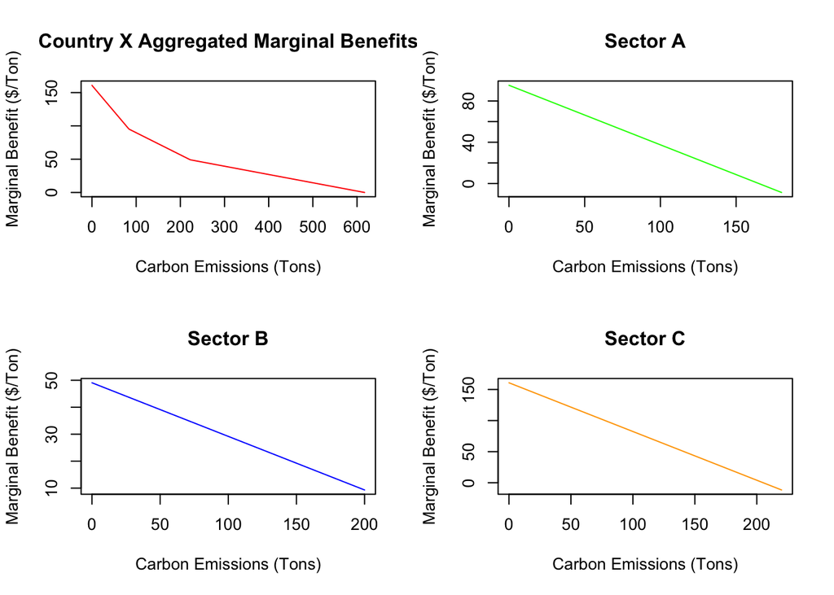

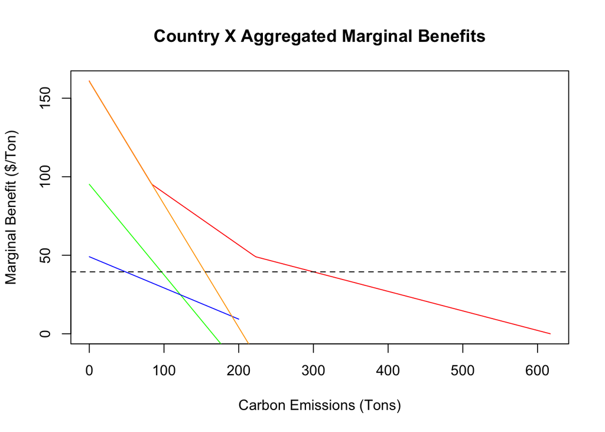

With a cap on carbon emissions, Sector A will emit 80 tons of carbon, Sector B will emit 100 tons, and Sector C will emit 120 tons. Each sector will abate 100 tons of carbon as mandated.

The cost of abatement for Sector A is 2,019.76, for Sector B is 1925.491, and for Sector C is 2,753.63. The total cost of meeting the cap of 300 tons of carbon emissions within Country X is 6,698.88. As the policy is simply a cap on emissions without an associated tax, there is no tax revenue generated.

Knowing that each sector needs to reduce its carbon emissions by 100 tons, it was possible to determine the amount that would each sector would need to abate. The total cost of abatement is the area under the marginal cost of abatement curve up to the total units that are abated. The benefit to the sector of still being able to emit some carbon is the area under the demand curve up to the total emitted units.

#### 3b. Tax on Carbon

If a tax is placed on each unit of carbon emitted in Country X, the optimal tax level is 39.43.

The optimal tax level for a cabon tax policy was determined by horizontally aggregating the demand curves for each sector. The intersection of the aggregate demand with 300 total units of carbon emitted is the level of the optimal carbon tax. The intersection of that tax with the demand curve for each sector is the amount of carbon that will be emitted. The tax revenue generated is equal to the tax price multiplied by the number of units emitted by each sector. Again, the abatement cost is equal to the area under the abatement curve to the value of units abated by each sector (the difference between emissions with no tax and with the tax), and the benefit of emitting is the area under the demand curve over to the number of units emitted.

#### 3c. Cap and Trade

The carbon trading price in a cap and trade scenario is equal to the optimal tax level identified in 3b. From that price it was possible to calculate the optimal number of units of carbon that each sector will emit. The difference between that level and the permits assigned under cap and trade is the number of offsets that a sector will either buy or sell, depending on their marginal price of abatement. When the abatement cost is lower than the trading price, the sector will abate and sell the offset, and when the abatement cost is higher than the trading price, the sector will purchase an offset.

### 4. Explore the inclusion of Country Y in the carbon market

In a carbon market that includes both Country X and Country Y, both country’s emissions would be capped at 300 tons and offsets could be traded between all 4 sectors. Sectors B and D would both sell offsets, and Sectors A and C would buy offsets.

Sector A will buy 33.35 offsets for 993.89. Sector B will sell 3.07 offsets and make 91.53. Sector C will buy 47.11 offsets for 1,403.96, and Sector D will sell 77.39 offsets for 2,306.32.

Because Sector D in Country Y would enter the market and has a lower marginal price of abatement for early units of carbon emissions, Sector D will sell offset permits. This was determined by aggregating the emissions curves across all 4 sectors, setting the cap, and determining the trading price for carbon emissions.

### 5. Every ton of carbon emissions creates 1 ton of local air pollution.

#### a. Carbon cap and trade market for Country X only

Country X produces: 300 Tons of air pollution

Country Y produces: 300 Tons of air pollution

#### b. Country Y enters the carbon market with Country X

If country Y enters the carbon market with Country X, Country X will have 377.39 units of air pollution and Country Y will have 222.61.

### c.

Allowing cap and trade will lead to an increase in the tons of air pollution in country x and decrease it in country y.